# Lecture 5: Model Validation

Babafemi Sorinolu

## Lecture Overview

Today we explore **Model Validation**—the core framework for evaluating, selecting, and tuning machine learning models.

1. **Data Splitting Strategy**: Training, Validation, & Testing sets
2. **Stratified Splitting**: Handling class imbalance
3. **Cross-Validation**: $K$-Fold & Leave-One-Out (LOO)
4. **Model Selection**: Impact of data splits & selection workflow
5. **Hyperparameter Tuning**: Grid Search & Model Optimization
6. **Validation Curves**: Diagnosing Bias vs. Variance

## How Do We Know If a Model Works?

We split the data into separate sets so that we can answer **three different questions**:

- **Train — *Can the model learn?***  
  Use the training data to estimate the model’s parameters.
- **Validate — *Which model should we use?***  
  Use the validation data to compare models, select among alternatives, and tune hyperparameters.
- **Test — *How well does the final model generalize?***  
  Use **unseen test data** to obtain an unbiased estimate of the final model’s performance.

**Train → Choose → Evaluate**

## Why is Cross-Validation Important?

- **Preventing Overfitting**: A model that memorizes training data will fail on new, unseen data.
- **Realistic Performance Estimation**: Evaluating on training data gives overly optimistic accuracy.
- **Data Efficiency**: Single train/test splits can lead to high variance depending on which samples fall into which set.
- **Robustness**: Cross-validation tests performance across multiple subsets to ensure reliability.

## Data Splitting: Train, Validation, and Test Sets

To properly train and evaluate models, we divide dataset $\mathcal{D}$ into three distinct sets:

| Set | Purpose | Fraction (Typical) |
| --- | --- | --- |
| **Training Set** | Fits the model parameters (weights/biases) | ~60% - 80% |
| **Validation Set** | Evaluates intermediate models & tunes hyperparameters | ~10% - 20% |
| **Testing Set** | Final unbiased evaluation of generalization error | ~10% - 20% |

> **Golden Rule**: Never use the **Test Set** for model selection or tuning! It must remain vault-locked until final evaluation.

## Stratified Splits

A sampling method that ensures each fold or split contains approximately the same percentage of samples of each target class as the complete dataset.

### When to Use?

- **Imbalanced Datasets**: e.g., Fraud detection (99% normal, 1% fraud).
- **Small Datasets**: Random splits might omit rare classes entirely from train or validation sets.
- **Classification Tasks**: Standard practice for single-label and multi-label classification.

## Code: Creating Train, Validation, and Test Sets

In `scikit-learn`, we can perform a 3-way split by calling `train_test_split` twice:

```python
from sklearn.model_selection import train_test_split
from sklearn.datasets import load_iris

# Load dataset
X, y = load_iris(return_X_y=True)

# Step 1: Split into Train+Val (80%) and Test (20%)
X_train_val, X_test, y_train_val, y_test = train_test_split(
    X, y, test_size=0.20, random_state=42, stratify=y
)

# Step 2: Split Train+Val into Train (75% of 80% = 60%) and Validation (25% of 80% = 20%)
X_train, X_val, y_train, y_val = train_test_split(
    X_train_val, y_train_val, test_size=0.25, random_state=42, stratify=y_train_val
)

print(f"Train: {X_train.shape[0]} | Val: {X_val.shape[0]} | Test: {X_test.shape[0]}")
```

[output not shown]

## K-Fold Cross-Validation

Split the training dataset into $K$ equal-sized subsets (folds).

1. Train the model on $K-1$ folds.
2. Validate the model on the remaining $1$ fold.
3. Repeat $K$ times, using each fold as validation once.
4. Compute the final performance metric as the average across all $K$ trials:

$$\text{CV Score} = \frac{1}{K} \sum_{i=1}^{K} \text{Score}_i$$

- **Common Values for $K$**: $K=5$ or $K=10$ (good trade-off between computational cost and bias/variance).

## Leave-One-Out Cross-Validation (LOO-CV)

An extreme case of $K$-Fold CV where $K = N$ ($N$ = total number of samples).

- For each iteration:
- Train on $N-1$ samples.
- Test on the single $1$ remaining sample.
- **Advantages**:
- Unbiased performance estimation (uses almost all data for training).
- Fully deterministic (no randomness in splitting).
- **Disadvantages**:
- High computational cost (fits $N$ separate models).
- High variance in evaluation error.

## Code: Leave-One-Out CV in Scikit-Learn

```python
from sklearn.model_selection import LeaveOneOut, cross_val_score
from sklearn.linear_model import LogisticRegression
from sklearn.datasets import load_iris

# Load dataset
X, y = load_iris(return_X_y=True)

# Initialize LeaveOneOut iterator
loo = LeaveOneOut()
model = LogisticRegression(max_iter=1000)

# Evaluate using LOO (fits 150 times for Iris dataset)
scores = cross_val_score(model, X, y, cv=loo, scoring='accuracy')

print(f"Number of fits (N): {len(scores)}")
print(f"LOO-CV Mean Accuracy: {scores.mean():.4f}")
```

[output not shown]

## Code: Implementing Cross-Validation in Scikit-Learn

```python
from sklearn.model_selection import cross_val_score, KFold, StratifiedKFold
from sklearn.ensemble import RandomForestClassifier

model = RandomForestClassifier(random_state=42)

# Standard 5-Fold CV
scores = cross_val_score(model, X, y, cv=5, scoring='accuracy')
print(f"5-Fold CV Accuracy: {scores.mean():.4f} (+/- {scores.std():.4f})")

# Custom Stratified K-Fold
skf = StratifiedKFold(n_splits=5, shuffle=True, random_state=42)
skf_scores = cross_val_score(model, X, y, cv=skf, scoring='accuracy')
print(f"Stratified 5-Fold Accuracy: {skf_scores.mean():.4f}")
```

[output not shown]

## Model Selection

**Model Selection** is the process of selecting the optimal machine learning algorithm (or architecture) among a set of candidate models for a given problem.

Examples of candidate models:

- Logistic Regression vs. Support Vector Machines vs. Decision Trees vs. Random Forests.

### Goal

Identify the model architecture that generalizes best to unseen data.

## What Makes a Good Model?

When comparing candidate models, consider:

- **Strong performance** — high accuracy, low mean squared error, etc.
- **Consistent performance** — similar results across cross-validation or different data splits.
- **Reasonable assumptions** — model assumptions are appropriate and not seriously violated.
- **Interpretability** — the model is understandable when interpretation is important.

### Key Idea

There is often **no single best model**.

We want a model that **generalizes well** while balancing:

**Performance + Consistency + Reasonable assumptions**

## Bias–Variance Tradeoff

A model’s ability to generalize depends on two sources of error:

- **Bias** — error from a model that is too simple to capture important patterns.
- **Variance** — error from a model that is too sensitive to the particular training data.

### The Tradeoff

- **High bias** → model **underfits** the data.
- **High variance** → model **overfits** the data.
- **Low bias + low variance** → better potential to **generalize** to unseen data.

The goal is not to minimize training error alone.

> **But to Choose a model that captures meaningful patterns without fitting noise.**

## Impact of Splits on Performance & Parameter Estimates

Single train/test splits can lead to volatile conclusions:

- **Metric Instability**: A lucky or unlucky split can inflate or deflate accuracy by several percentage points.
- **Parameter Sensitivity**: Model coefficients (or tree structures) vary wildly depending on which samples end up in the training set.
- **Cross-Validation Solution**: Averaging metrics across $K$ folds reduces estimate variance and provides a confidence interval ($\text{mean} \pm \text{std}$).

## Steps for Model Selection with Cross-Validation

1. **Split Data**: Reserve a holdout Test Set ($10\% - 20\%$).
2. **Define Candidate Models**: List algorithm families to compare.
3. **Evaluate via CV**: Perform $K$-Fold CV on the training set for each candidate.
4. **Compare Performance**: Compute mean and standard deviation of validation metrics across folds.
5. **Select Best Model**: Choose the model family with the superior CV score.
6. **Refit & Test**: Re-train selected model on the entire training set and evaluate on the holdout Test Set.

## Code: Implementing Model Selection with CV

```python
from sklearn.linear_model import LogisticRegression
from sklearn.svm import SVC
from sklearn.ensemble import RandomForestClassifier
from sklearn.model_selection import cross_val_score

models = {
    "Logistic Regression": LogisticRegression(max_iter=1000),
    "Support Vector Machine": SVC(),
    "Random Forest": RandomForestClassifier(random_state=42)
}

# Evaluate candidates on training portion
for name, clf in models.items():
    cv_scores = cross_val_score(clf, X_train_val, y_train_val, cv=5)
    print(f"{name}: Mean CV Accuracy = {cv_scores.mean():.4f} (std: {cv_scores.std():.4f})")
```

[output not shown]

## Hyperparameter vs. Parameter & Model Tuning

### Parameters vs. Hyperparameters

- **Parameters**: Learned directly from data during training (e.g., weights $w$, bias $b$, split points in trees).
- **Hyperparameters**: Configured *before* training to control learning behavior (e.g., learning rate $\alpha$, $C$ in SVM, `max_depth` in Decision Trees).

### Model Tuning

The process of searching for the combination of hyperparameters that yields optimal model validation performance.

## `sklearn` methods

- `sklearn` provides two main methods for hyperparameter optimization
- Grid Search — systematically evaluates every combination in a predefined grid.
- Random Search — randomly samples configurations from specified distributions.

The choice of search strategy depends largely on the size and structure of the hyperparameter space.

## Setting a Tuning Grid & Grid Search

A **Tuning Grid** defines a discrete search space over hyperparameter values.

```python
param_grid = {
    'n_estimators': [50, 100, 200],
    'max_depth': [3, 5, 10, None],
    'min_samples_split': [2, 5]
}
```

- **GridSearchCV**: Evaluates all $3 \times 4 \times 2 = 24$ combinations using $K$-Fold cross-validation.
- **Selection**: Picks the combination that yields the highest mean CV score.

## Grid Search

- Covers all possible combinations from the provided grid.
- Can be parallelized easily.
- Integrates cross-validation.

## What Does GridSearchCV Do?

- Generates all hyperparameter combinations.
- Trains and evaluates each combination using cross-validation.
- Calculates the mean CV score for each configuration.
- Identifies the configuration with the highest mean CV score.

The best configuration can be accessed with:

```python
#| eval: false

grid_search.best_params_
```

## Random Search

- More efficient than grid search when dealing with large hyperparameter spaces.
- Samples a given number of parameter settings from distributions.

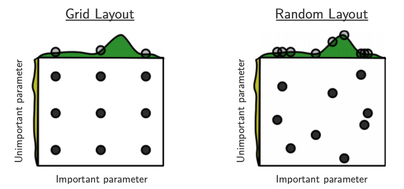

## Random search example

```python
from sklearn.model_selection import RandomizedSearchCV
from scipy.stats import randint

pipe_svc = make_pipeline(CountVectorizer(), SVC())

param_dist = {
    "countvectorizer__max_features": randint(100, 2000),
    "svc__C": uniform(0.1, 1e4),  # loguniform(1e-3, 1e3),
    "svc__gamma": loguniform(1e-5, 1e3),
}
random_search = RandomizedSearchCV(pipe_svm,
                                  param_distributions = param_dist,
                                  n_iter=10,
                                  n_jobs=-1,
                                  return_train_score=True)

# Carry out the search
random_search.fit(X_train, y_train)
random_search.best_score_
```

## Code: Implementing Model Tuning in Scikit-Learn

```python
#| eval: false

from sklearn.model_selection import GridSearchCV
from sklearn.ensemble import RandomForestClassifier

# Define candidate model and search space
rf = RandomForestClassifier(random_state=42)
param_grid = {
    'n_estimators': [25, 50, 100],
    'max_depth': [3, 5, None],
    'min_samples_split': [2, 5]
}

# Set up Grid Search with 5-Fold CV
grid_search = GridSearchCV(estimator=rf, param_grid=param_grid, cv=5, scoring='accuracy', n_jobs=-1)
grid_search.fit(X_train_val, y_train_val)

print("Best Parameters:", grid_search.best_params_)
print(f"Best CV Accuracy: {grid_search.best_score_:.4f}")

# Evaluate optimal model on holdout test set
best_model = grid_search.best_estimator_
test_accuracy = best_model.score(X_test, y_test)
print(f"Final Holdout Test Accuracy: {test_accuracy:.4f}")
```

# Optimization bias

## Pizza baking competition example

Imagine that you participate in pizza baking competition.

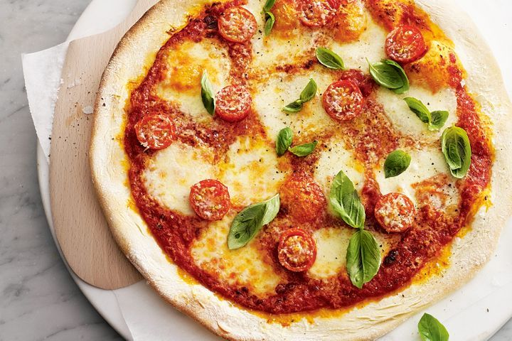

- **Training phase**: Collecting recipes and practicing at home
- **Validation phase**: Inviting a group of friends for tasting and feedback
- **Test phase (competition day)**: Serving the judges

## Overfitting on the validation set

- Your friends loved your pineapple pizza.
- You fine-tune your recipe for the same group of friends, perfecting it for their tastes.

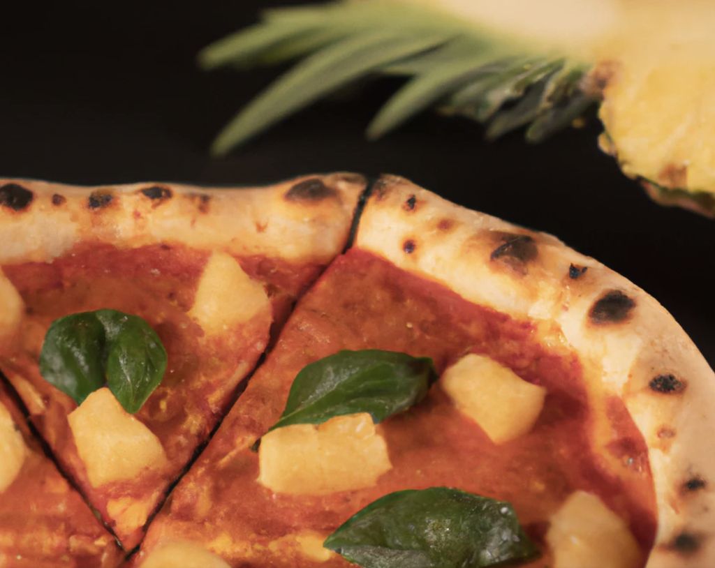

- On the competition day, you confidently present your perfected pineapple pizza.
- Judges are not impressed: *“This doesn’t appeal to a broad audience.”*

[figure not shown]

This is similar to reusing the same validation set again and again to perfect the model for it!

## Lesson: Overfitting on the validation set

- You tailored your recipe too closely to your friends’ tastes.
- They were **not representative** of the broader audience (the judges).
- The pizza, while perfect for your validation group, failed to **generalize**.
- Over many iterations, the validation set no longer gives an **unbiased estimate** of performance.
- That’s why we need a **separate test set** (like a group of tasters who never influenced your pizza).

## Optimization bias

- Why do we need separate validation and test datasets?

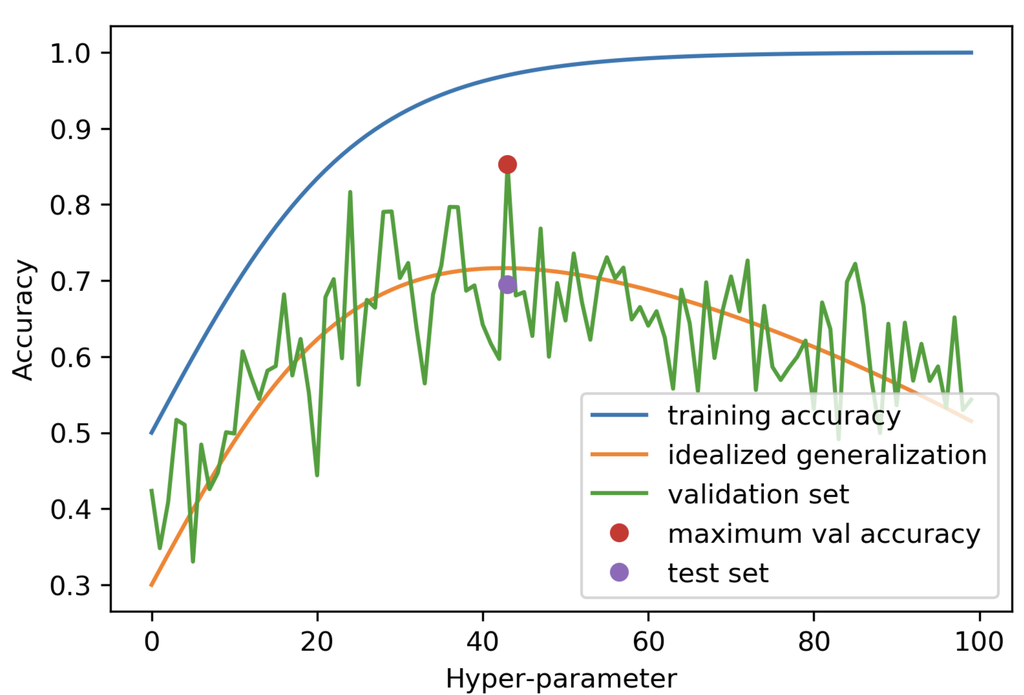

## Mitigating optimization bias

- Cross-validation
- Ensembles
- Regularization and choosing a simpler model

## Interpreting Validation Curves

A **Validation Curve** plots training and validation scores against a single hyperparameter’s values.

Validation curves are useful for detecting overfitting: - Hyperparameters that are overfitted will have high training scores and low validation scores. - Optimal hyperparameters will perform well on the training sets and the validation sets.

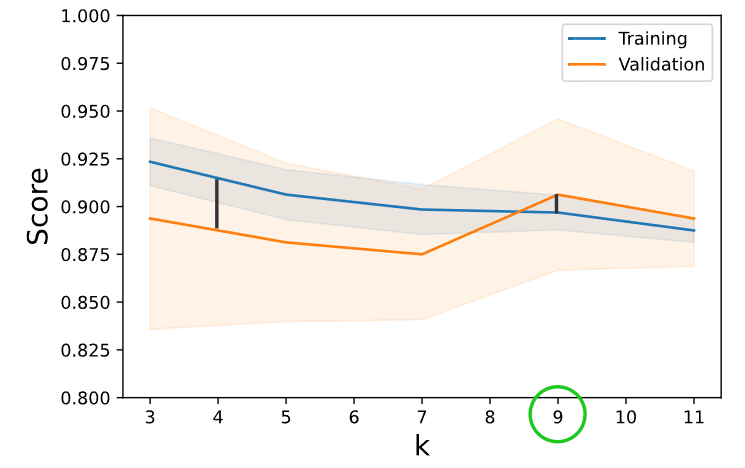

## Code: Plotting a Validation Curve

```python
#| eval: false

import numpy as np
import matplotlib.pyplot as plt
from sklearn.model_selection import validation_curve
from sklearn.tree import DecisionTreeClassifier

param_range = np.arange(1, 11)
train_scores, val_scores = validation_curve(
    DecisionTreeClassifier(random_state=42), X_train_val, y_train_val,
    param_name="max_depth", param_range=param_range, cv=5, scoring="accuracy"
)

train_mean, val_mean = np.mean(train_scores, axis=1), np.mean(val_scores, axis=1)

plt.figure(figsize=(8, 4))
plt.plot(param_range, train_mean, label="Training Score", color="blue", marker="o")
plt.plot(param_range, val_mean, label="Validation Score", color="red", marker="o")
plt.xlabel("Max Depth")
plt.ylabel("Accuracy")
plt.title("Validation Curve for Decision Tree")
plt.legend(loc="best")
plt.grid(True)
plt.show()
```

## Summary of Best Practices

1. **Keep the Test Set untouched** until all model selection and hyperparameter tuning is finished.
2. **Use Stratified Splitting** whenever dealing with classification tasks.
3. **Leverage Cross-Validation** ($K=5$ or $K=10$) for reliable performance assessment and model selection.
4. **Tune Hyperparameters** systematically with `GridSearchCV` or `RandomizedSearchCV`.
5. **Diagnose with Validation Curves** to detect underfitting vs. overfitting before deploying models.